# Analiza klientów firmy doradczej

Wiktor Lamch

01 11 2020

```r
#Ładowanie niezbędnych pakietów i ustawianie stylu wykresów
library(tidyverse)
library(lubridate)
library(GGally)
library(randomForest)
library(psych)
library(Hmisc)
library(broom)
library(cowplot)
theme_set(theme_light())
```

# W analizie zostanie zbadany wpływ zmiennych na zyski osiągane przez firmę doradczą z firm będących jej klientami.

## Hipoteza badawcza brzmi: Czym charakteryzują się firmy, które przynoszą firmie doradczej duże zyski a czym te, które przynoszą niewielkie?

### Wczytywanie i przygotowanie danych.

#### Zmienna id nie niesie za sobą żadnych informacji. Jej wartości jednoznacznie identyfikują obserwacje. W związku z tym zostanie ona usunięta ze zbioru. Dodatkowo do zbioru danych zostanie dodana zmienna rok_rejestracji oraz rok_ostatniego_zamowienia. Zmienne zawierające miesiące nie są informatywne więc nie zostaną dodane do zbioru.

```r
firmy <- read.csv2("klienci_firmy_doradczej.csv", na.strings = "") %>%
  mutate(data_rejestracji = dmy(data_rejestracji),
         data_ostatnie_zamowienie = dmy(data_ostatnie_zamowienie),
         kod_branzy = as.character(kod_branzy),
         rok_rejestracji = year(data_rejestracji),
         rok_ostatniego_zamowienia = year(data_ostatnie_zamowienie)) %>%
  select(-c("id", "data_rejestracji", "data_ostatnie_zamowienie"))

firmy %>% head()
```

```
##   nazwa_wojewodztwa kod_rynku kod_branzy liczba_pracownikow zrodlo_rejestr
## 1         pomorskie       GDW      10001        51-100 osób            KRS
## 2         pomorskie       GDW        907           2-5 osób          CEIDG
## 3           śląskie       KTW        411            1 osoba          CEIDG
## 4           śląskie       KTW        411          6-10 osób          CEIDG
## 5           śląskie       KTW        411          6-10 osób          CEIDG
## 6           śląskie       KTW        755           2-5 osób          CEIDG
##   obecnosc_w_internecie target_wartosc_sprzedazy rok_rejestracji
## 1         ma stronę www                     4500            1990
## 2            e-commerce                     1605            1992
## 3         ma stronę www                      540            2011
## 4         ma stronę www                      650            1989
## 5         ma stronę www                      250            1999
## 6         ma stronę www                      500            1992
##   rok_ostatniego_zamowienia
## 1                      2020
## 2                      2020
## 3                      2020
## 4                      2018
## 5                      2018
## 6                      2018
```

```r
firmy %>% Hmisc::describe()
```

```
## .
##
##  9  Variables      14512  Observations
## --------------------------------------------------------------------------------
## nazwa_wojewodztwa
##        n  missing distinct
##    14512        0       16
##
## lowest : dolnośląskie        kujawsko-pomorskie  lubelskie           lubuskie            łódzkie
## highest: śląskie             świętokrzyskie      warmińsko-mazurskie wielkopolskie       zachodniopomorskie
##
## dolnośląskie (1018, 0.070), kujawsko-pomorskie (792, 0.055), lubelskie (669,
## 0.046), lubuskie (422, 0.029), łódzkie (954, 0.066), małopolskie (1333, 0.092),
## mazowieckie (2056, 0.142), opolskie (337, 0.023), podkarpackie (530, 0.037),
## podlaskie (342, 0.024), pomorskie (1202, 0.083), śląskie (1800, 0.124),
## świętokrzyskie (386, 0.027), warmińsko-mazurskie (596, 0.041), wielkopolskie
## (1307, 0.090), zachodniopomorskie (768, 0.053)
## --------------------------------------------------------------------------------
## kod_rynku
##        n  missing distinct
##    14512        0       57
##
## lowest : BBW BDW BIW BPW CHW, highest: WBW WLW WRW ZGW ZMW
## --------------------------------------------------------------------------------
## kod_branzy
##        n  missing distinct
##    14512        0       18
##
## lowest : 10001 1171  1386  1387  1402 , highest: 755   848   907   968   98
##
## Value      10001  1171  1386  1387  1402  1433  1574   411   437     5   522
## Frequency    761   701   792   686   577   541  1077  1045   915  1057   881
## Proportion 0.052 0.048 0.055 0.047 0.040 0.037 0.074 0.072 0.063 0.073 0.061
##
## Value        526   652   755   848   907   968    98
## Frequency    997   657   891   831   523   640   940
## Proportion 0.069 0.045 0.061 0.057 0.036 0.044 0.065
## --------------------------------------------------------------------------------
## liczba_pracownikow
##        n  missing distinct
```

[output cut: 38 more lines]

```
##        n  missing distinct     Info     Mean      Gmd      .05      .10
##    14512        0       69    0.997     2009    10.22     1992     1995
##      .25      .50      .75      .90      .95
##     2003     2012     2017     2018     2019
##
## lowest : 1909 1920 1922 1926 1946, highest: 2016 2017 2018 2019 2020
## --------------------------------------------------------------------------------
## rok_ostatniego_zamowienia
##        n  missing distinct     Info     Mean      Gmd
##    14512        0        3    0.878     2019   0.9078
##
## Value       2018  2019  2020
## Frequency   4376  4074  6062
## Proportion 0.302 0.281 0.418
## --------------------------------------------------------------------------------
```

#### Zmienna liczba_pracownikow posiada 9325 wartości brakujących. Stanowią one 64,26% wszystkich obserwacji.

```r
sumna <- function(x) sum(is.na(x))

firmy %>% summarise_all(sumna)
```

```
##   nazwa_wojewodztwa kod_rynku kod_branzy liczba_pracownikow zrodlo_rejestr
## 1                 0         0          0               9325              0
##   obecnosc_w_internecie target_wartosc_sprzedazy rok_rejestracji
## 1                     0                        0               0
##   rok_ostatniego_zamowienia
## 1                         0
```

```r
paste0("Procent brakujących obserwacji dla zmiennej liczba_pracownikow: ",
       mean(is.na(firmy$liczba_pracownikow)) %>% round(., 4) * 100, "%")
```

```
## [1] "Procent brakujących obserwacji dla zmiennej liczba_pracownikow: 64.26%"
```

#### Rozkład zmiennej docelowej jest skrajnie asymetryczny. Charakretyzuje się bardzo silną prawostronną asymetrią.

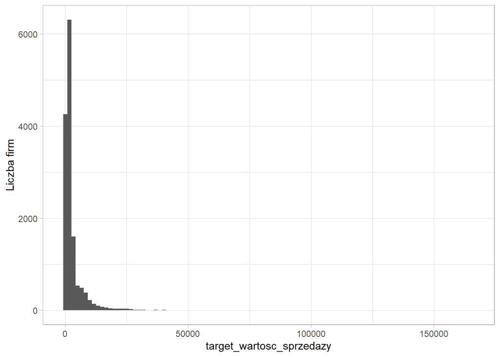

```r
firmy %>% ggplot(aes(target_wartosc_sprzedazy))+
  geom_histogram(bins = 100)+
  ylab("Liczba firm")
```

#### Obserwacje odstające zostaną wyeliminowane z dalszej analizy. Zostanie do tego użyta reguła 1.5 wartości rozstępu międzykwartylowego.

```r
IQR <- quantile(firmy$target_wartosc_sprzedazy, 0.75) - quantile(firmy$target_wartosc_sprzedazy, 0.25)
upper_boundary <- quantile(firmy$target_wartosc_sprzedazy, 0.75) + 1.5 * IQR
```

#### Granica wyznaczająca obserwacje odstające

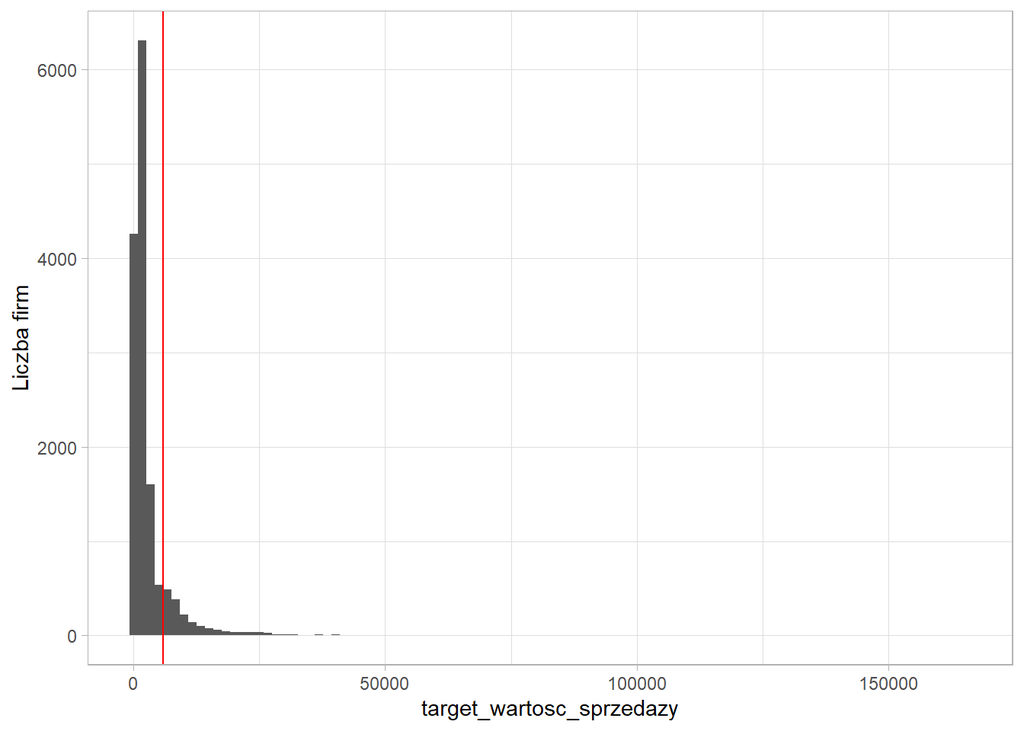

```r
firmy %>% ggplot(aes(target_wartosc_sprzedazy))+
  geom_histogram(bins = 100)+
  ylab("Liczba firm")+
  geom_vline(aes(xintercept = upper_boundary), show.legend = T, col = "red")
```

#### Zostało odrzuconych 1797 obserwacji, co stanowi 12% całego zbioru. W porównaniu do liczby obserwacji w analizowanym zbiorze, ubytek ten nie spowoduje utraty informacji.

```r
firmy_duza_sprzedaz <- firmy %>% filter(target_wartosc_sprzedazy > upper_boundary)
```

```r
paste("Liczba obserwacji odstajcych:", sum(firmy$target_wartosc_sprzedazy > upper_boundary))
```

```
## [1] "Liczba obserwacji odstajcych: 1797"
```

```r
paste0("Procent obserwacji odstajcych: ", round(mean(firmy$target_wartosc_sprzedazy > upper_boundary) * 100, 2), "%")
```

```
## [1] "Procent obserwacji odstajcych: 12.38%"
```

```r
firmy <- firmy %>% filter(target_wartosc_sprzedazy <= upper_boundary)
```

#### Rozkład zmiennej target_wartosc_sprzedazy po usunięciu obserwacji odstających ze zbioru.

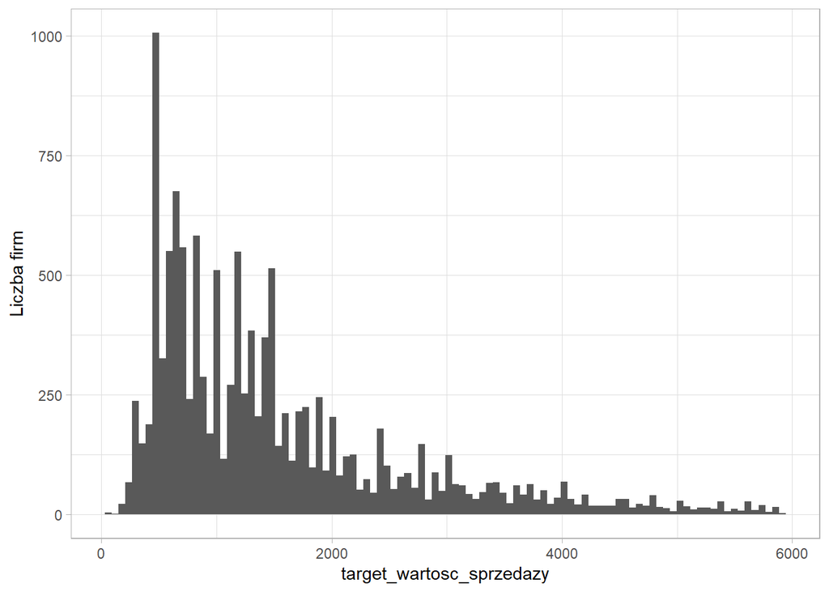

```r
firmy %>%
  ggplot(aes(target_wartosc_sprzedazy))+
  geom_histogram(bins = 100)+
  ylab("Liczba firm")
```

# Zmienne numeryczne

#### Poniższy wykres liniowy przedstawia medianę wartości osiąganych przez firmy w zależności od roku rejestracji. Do roku 1980 mediana wartości sprzedaży charakteryzuje się bardzo dużym zróżnicowaniem. Tak duża zmienność może utrudniać wyciąganie wniosków w dalszej analizie, więc gdy firm zarejestrowanych do 1990 roku będzie niewiele, zostaną one usunięte ze zbioru danych. Dodatkowo gdy firm zarejestrowanych przed 1990 rokiem jest niewiele to wyliczone dla tych lat mediany mogą być obarczone zbyt dużym błędem statystycznym.

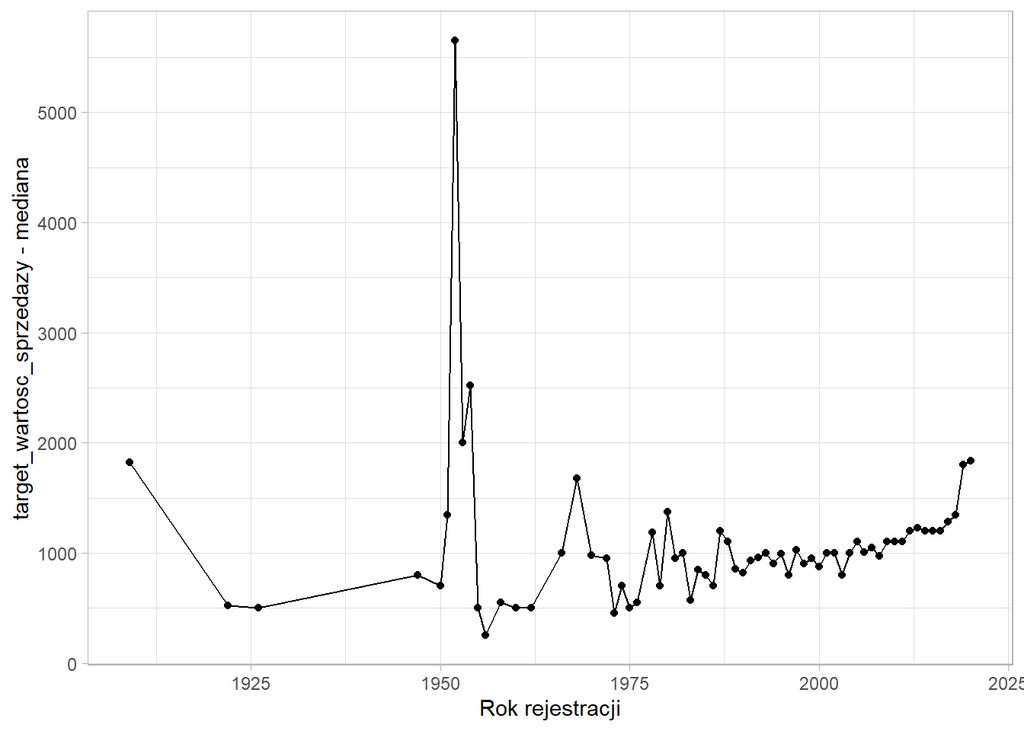

```r
firmy %>%
  group_by(rok_rejestracji) %>%
  summarise(target_wartosc_sprzedazy = median(target_wartosc_sprzedazy)) %>%
  ggplot(aes(rok_rejestracji, target_wartosc_sprzedazy))+
  geom_point()+
  geom_line()+
  xlab("Rok rejestracji")+
  ylab("target_wartosc_sprzedazy - mediana")
```

#### Poniżej widać, że firm zarejestrowanych przed 1990 rokiem jest niewiele. Jest ich 284 co stanowi 2,23% firm znajdujących się w zbiorze danych. W związku z tym zostana one usunięte ze zbioru.

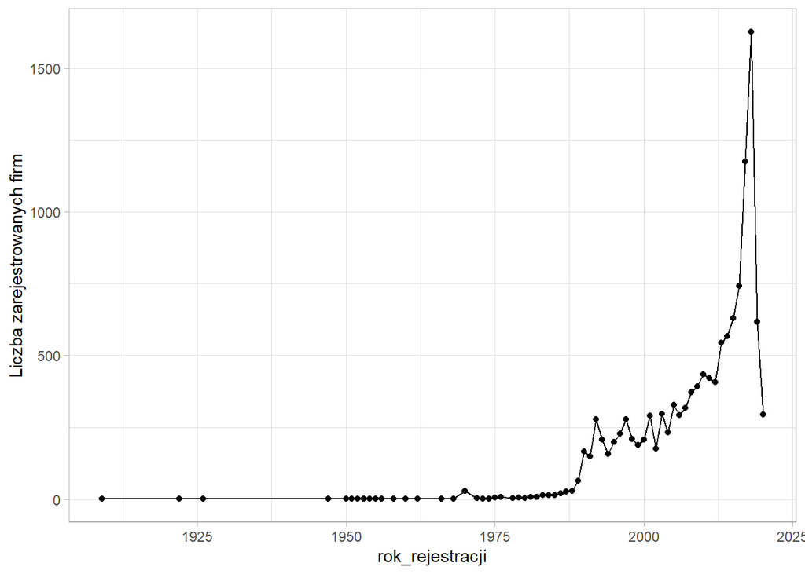

```r
firmy %>%
  count(rok_rejestracji) %>%
  ggplot(aes(rok_rejestracji, n))+
  geom_point()+
  geom_line()+
  ylab("Liczba zarejestrowanych firm")
```

```r
paste("Liczba firm zarejestrowanych przed 1990 rokiem:", sum(firmy$rok_rejestracji < 1990))
```

```
## [1] "Liczba firm zarejestrowanych przed 1990 rokiem: 284"
```

```r
paste0("Procent firm zarejestrowanych przed 1990 rokiem: ", round(mean(firmy$rok_rejestracji < 1990) * 100, 2),"%")
```

```
## [1] "Procent firm zarejestrowanych przed 1990 rokiem: 2.23%"
```

```r
firmy <- firmy %>% filter(rok_rejestracji >= 1990)
```

#### Na podstawie oczyszczonych danych można łatwo zauważyć, że firmy później zarejestrowane pozwalają na osiągnięcie wyższych zysków. Można wywnioskować, że rok rejestracji jest dodatnio skorelowany z wartością sprzedaży. Zależność ta jednak nie ma liniowego charakteru.

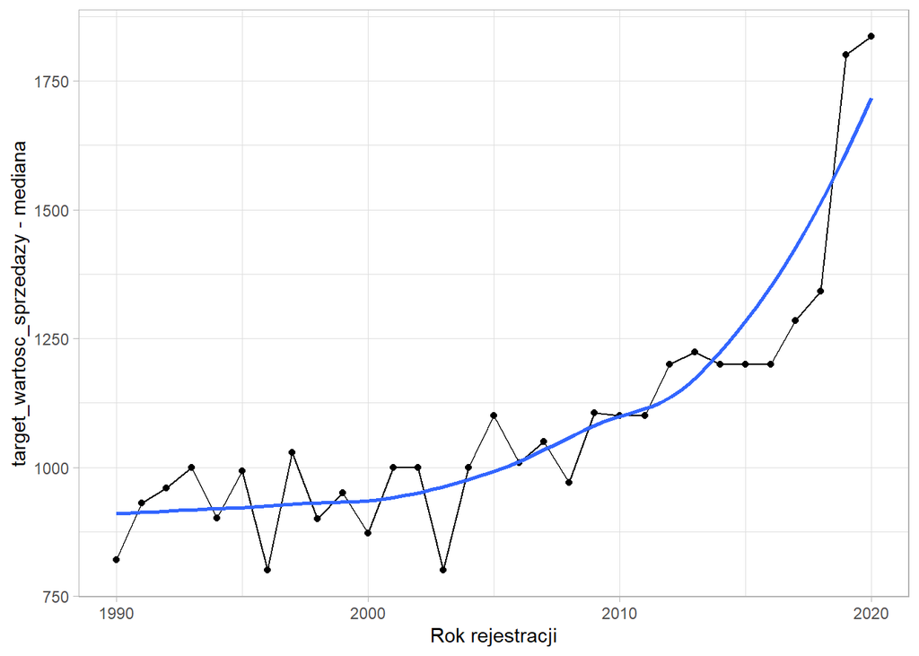

```r
firmy %>%
  group_by(rok_rejestracji) %>%
  summarise(target_wartosc_sprzedazy = median(target_wartosc_sprzedazy)) %>%
  ggplot(aes(rok_rejestracji, target_wartosc_sprzedazy))+
  geom_point()+
  geom_line()+
  geom_smooth(se = F)+
  xlab("Rok rejestracji")+
  ylab("target_wartosc_sprzedazy - mediana")
```

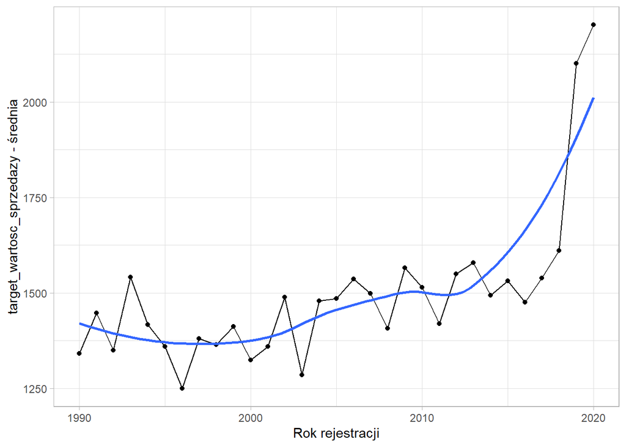

```r
firmy %>%
  group_by(rok_rejestracji) %>%
  summarise(target_wartosc_sprzedazy = mean(target_wartosc_sprzedazy)) %>%
  ggplot(aes(rok_rejestracji, target_wartosc_sprzedazy))+
  geom_point()+
  geom_line()+
  geom_smooth(se = F)+
  xlab("Rok rejestracji")+
  ylab("target_wartosc_sprzedazy - średnia")
```

#### Rok ostatniego zamówienia dość dobrze różnicuje wartość sprzedaży. Firmy które ostatni raz złożyły zamówienie w 2018 roku cechują się niższą wartością zmiennej docelowej. Czyżby to klienci niezbyt chętnie korzystający z usług, którzy już zrezygnowali ?

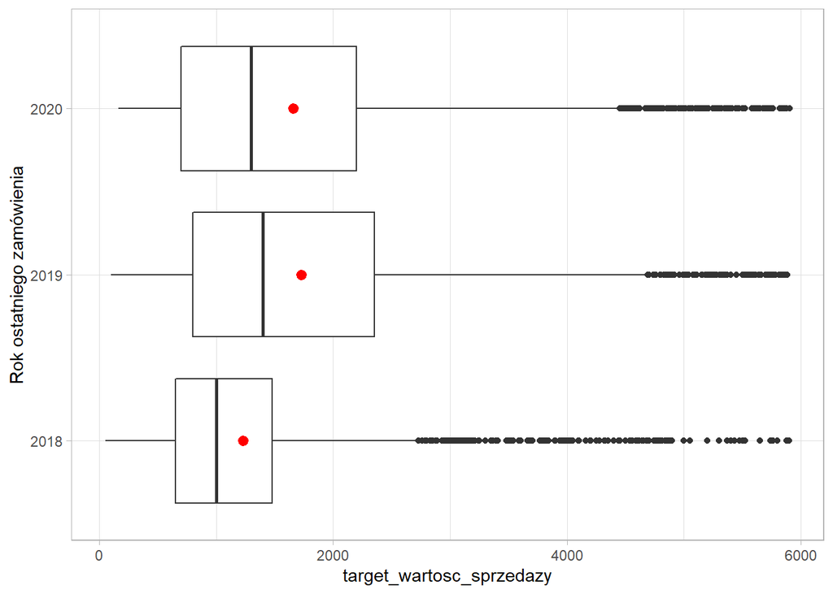

```r
firmy %>%
  ggplot(aes(as.factor(rok_ostatniego_zamowienia), target_wartosc_sprzedazy))+
  geom_boxplot()+
  coord_flip()+
  stat_summary(fun.y="mean", col = "red")+
  xlab("Rok ostatniego zamówienia")
```

# Zmienne nienumeryczne

### Aby nie duplikować kodu zostaną stworzone funkcje do wyświetlania wykresów

```r
make_barplot <- function(data = firmy, zmienna = "kod_rynku", xlab = "Kod rynku",
                         ylab = "Liczba firm", lab_size = 9){
  data %>%
  count(data[[zmienna]]) %>%
  rename(zmienna = 1) %>%
  ggplot(aes(x = fct_reorder(zmienna, n, sum), y = n))+
  geom_col()+
  coord_flip()+
  xlab(xlab)+
  ylab(ylab)+
  theme(axis.text = element_text(size = lab_size))
}


make_boxplots <- function(data = firmy, zmienna = "kod_rynku", xlab = "Kod rynku", lab_size = 9){
  data[,c(zmienna, "target_wartosc_sprzedazy")] %>%
  rename(zmienna = 1) %>%
  ggplot(aes(fct_reorder(zmienna, target_wartosc_sprzedazy), target_wartosc_sprzedazy))+
  geom_boxplot()+
  coord_flip()+
  stat_summary(fun="mean", col = "red")+
  xlab(xlab)+
  theme(axis.text = element_text(size = lab_size))
}
```

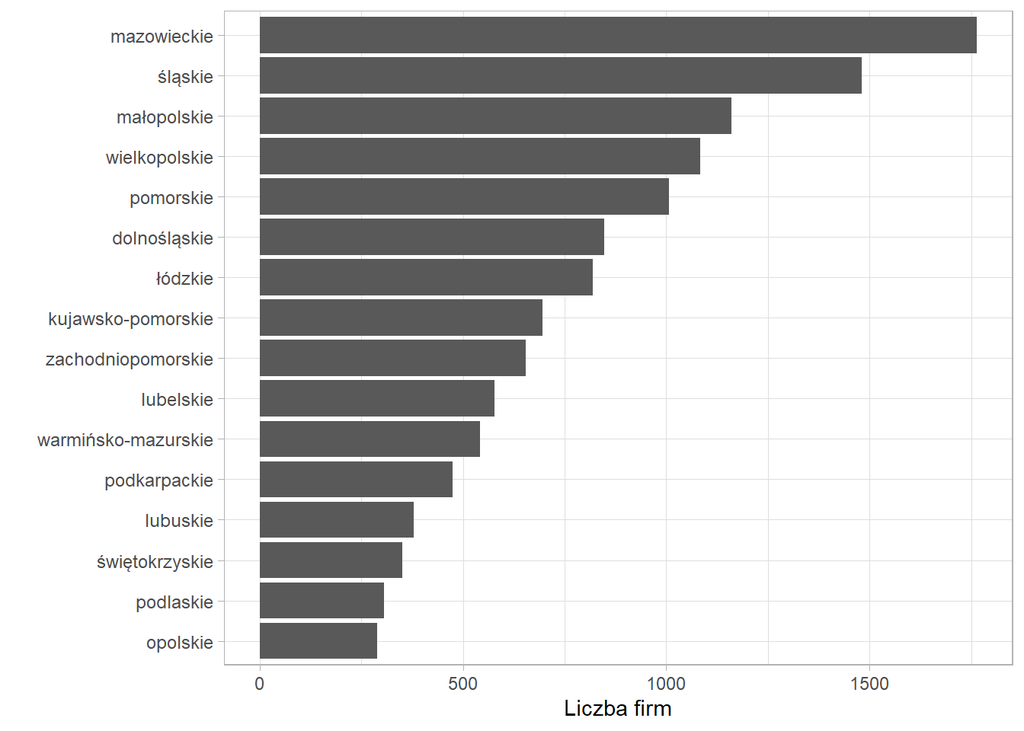

```r
make_barplot(zmienna = "nazwa_wojewodztwa", , xlab = "")
```

#### Na poniższych wykresach widać, że województwo nie ma istotnego wpływu na wartość sprzedaży. Zarówno wartości mediany jak i średnie arytmetyczne (oznaczone czerwonymi kropkami) nie różnią się od siebie istotnie. Widać również, że zakresy międzykwartylowe na poniższych wykresach są podobne. Jedynie województwo lubuskie i podlaskie nieco odbiegają od reszty.

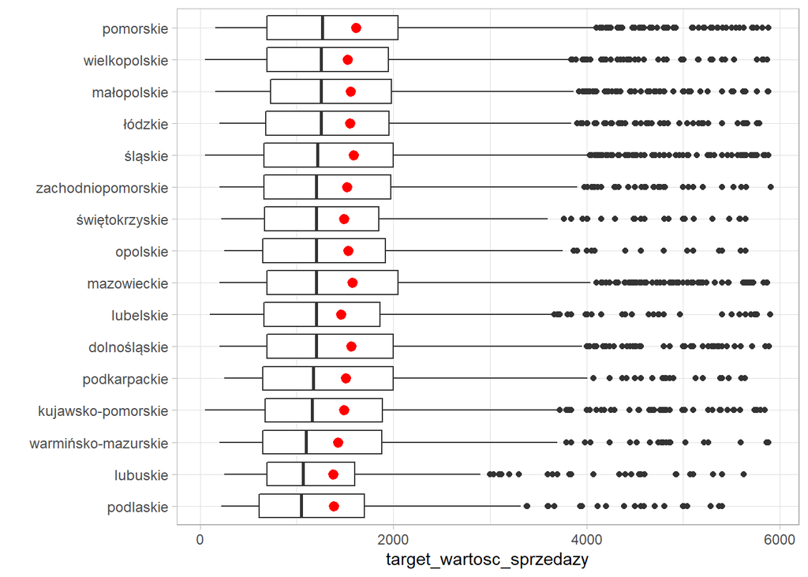

```r
make_boxplots(zmienna = "nazwa_wojewodztwa", xlab = "")
```

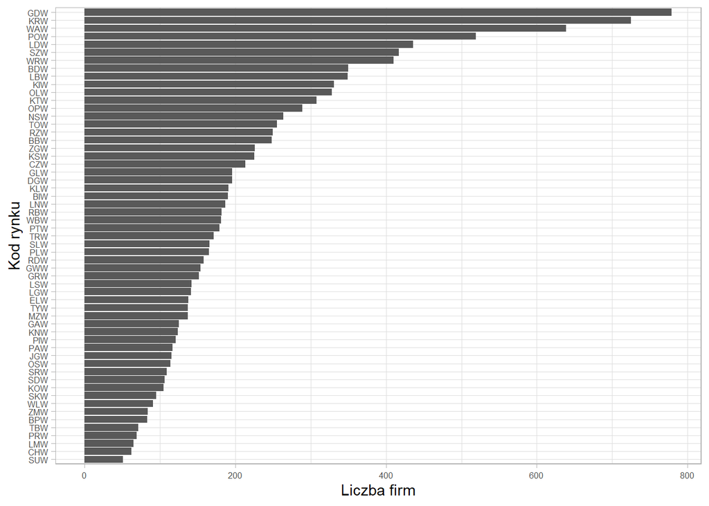

```r
make_barplot(zmienna = "kod_rynku", xlab = "Kod rynku", lab_size = 6)
```

#### Kod rynku bardziej różnicuje wartość sprzedaży. Firmy o kodach “LSW” i “TYW” cechują się nieco większą wartością mediany. Pomimo tego ciężko jest zaobserwować istotny wzorzec, który pozwoliłby na stwierdzenie, że ta zmienna istotnie wpływa na poziom wartości sprzedaży.

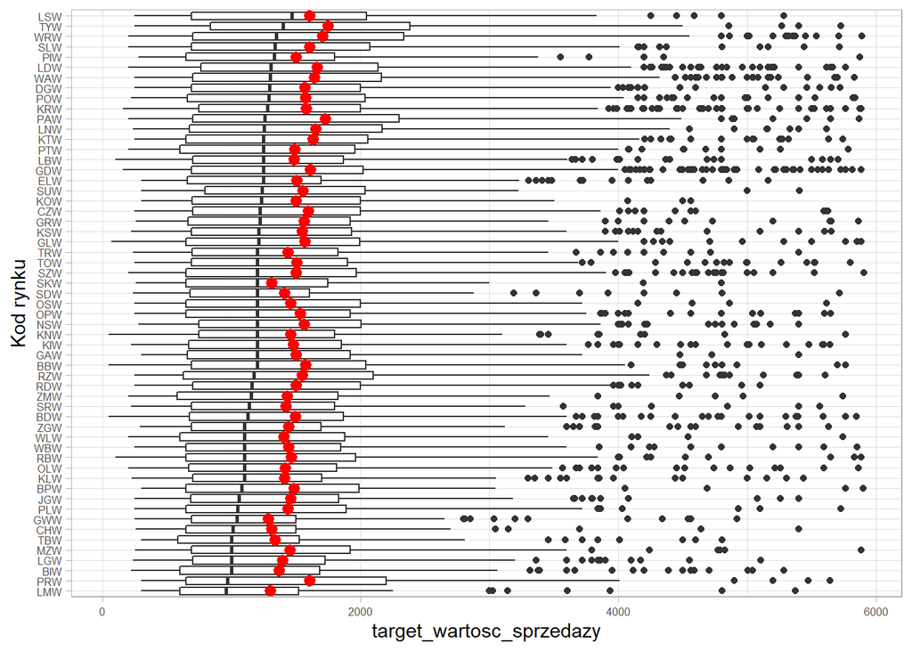

```r
make_boxplots(zmienna = "kod_rynku", xlab = "Kod rynku", lab_size = 6)
```

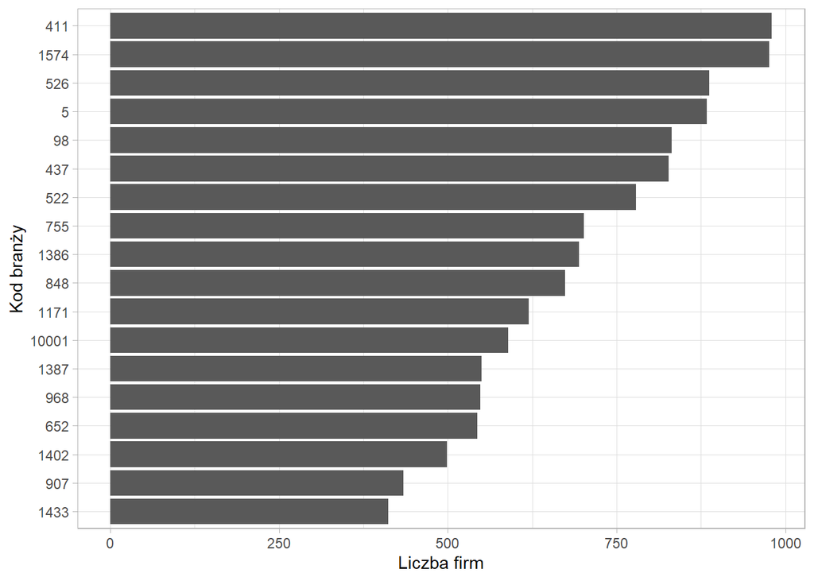

```r
make_barplot(zmienna = "kod_branzy", xlab = "Kod branży")
```

#### Kod 1387 i 652 cechują się największymi wartościami średniej i mediany. Branża o kodzie 755 z kolei najniższymi. Dosyć wyraźne różnice w rozkładach wartości sprzedaży dla firm działających w branżach o wymienionych kodach mogą przyczynić się do istotnego wpływu tej zmiennej na zmienną docelową.

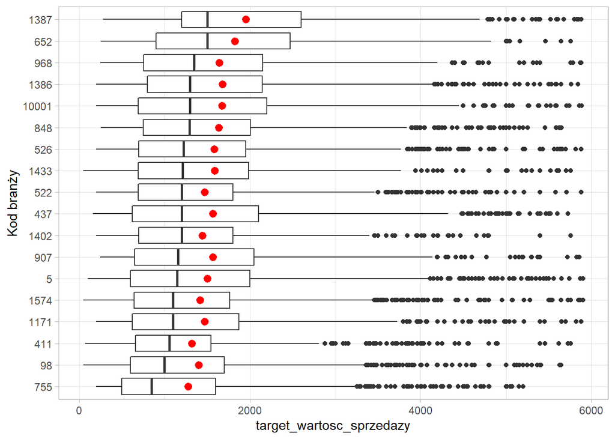

```r
make_boxplots(zmienna = "kod_branzy", xlab = "Kod branży")
```

#### Firm zartudniających powyżej 10 osób jest w analizowanym zbiorze bardzo niewiele. Pomimo tego widać, że większe firmy zatrudniające powyżej 10 osób mają przeciętnie wyższą wartość sprzedaży od pozostałych. Jak wspomniano powyżej, ponad 60% obserwacji tej zmiennej nie ma przypisanej żadnej kategorii.

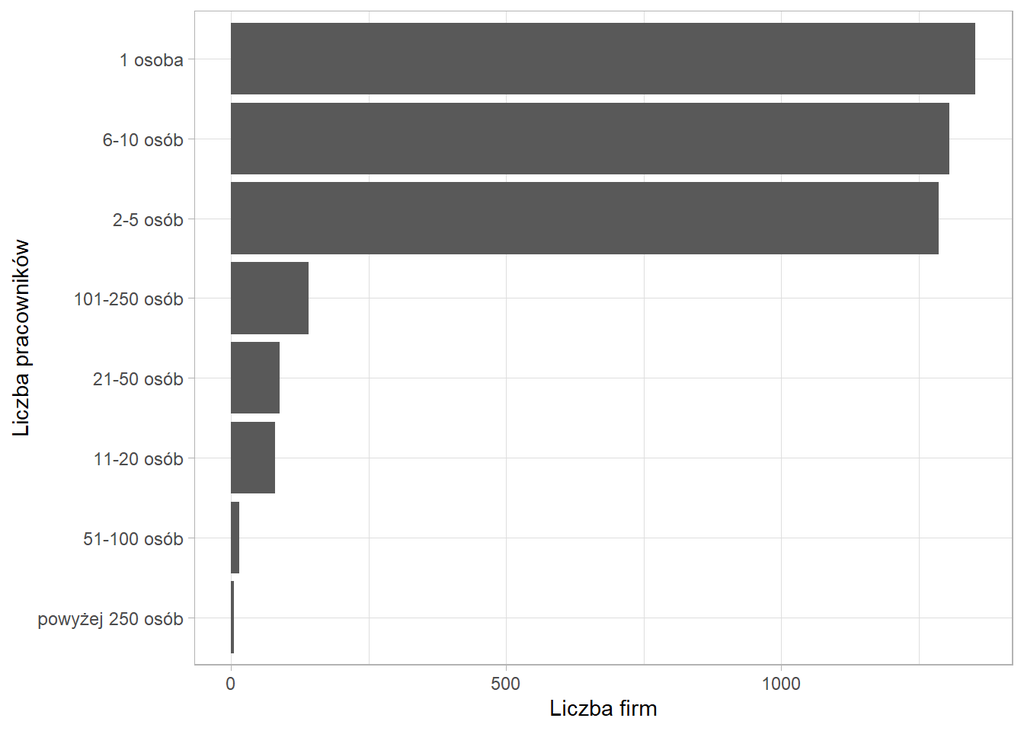

```r
make_barplot(data = firmy %>% na.omit(), zmienna = "liczba_pracownikow", xlab = "Liczba pracowników")
```

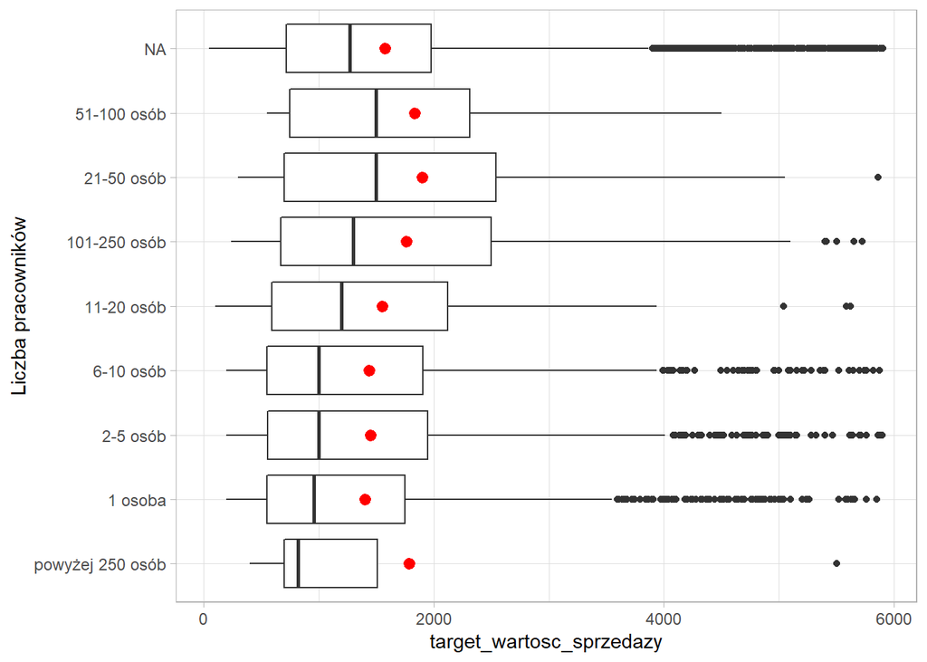

```r
make_boxplots(zmienna = "liczba_pracownikow", xlab = "Liczba pracowników")
```

#### W KRS w rejestrze przedsiębiorców są przede wszystkim zarejestrowane spółki osobowe oraz kapitałowe. W CEIDG natomiast osoby fizyczne prowadzące działalność gospodarczą. Spółki osobowe i kapitałowe mają przeważnie większy kapitał, a co za tym idzie większe obroty (można to zauważyć na wykresach pudełkowych). Zmienna ta charakteryzuje się dużą dysproporcją. Może to spowodować niewielką informatywność tej zmiennej. Niemniej jednak, korzystając z wiedzy ogólnej, zostanie ona poddana dalszej analizie.

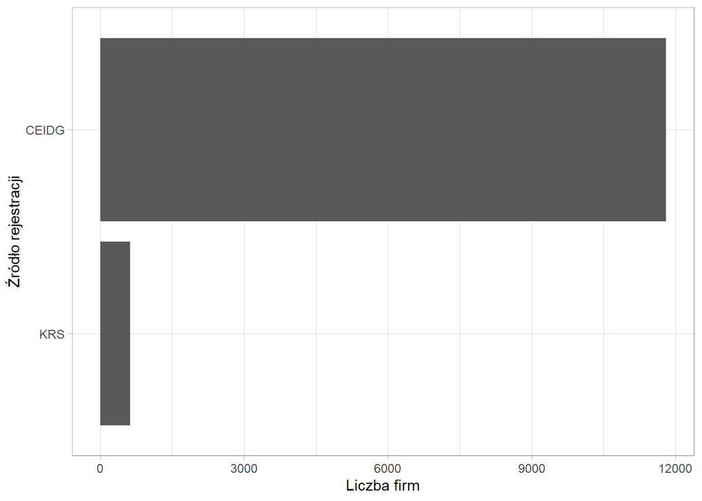

```r
make_barplot(zmienna = "zrodlo_rejestr", xlab = "Źródło rejestracji")
```

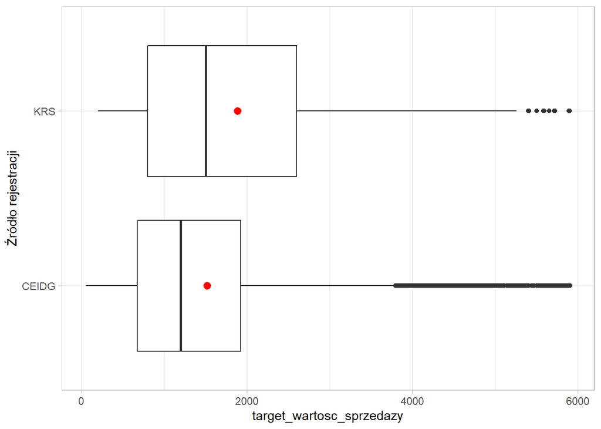

```r
make_boxplots(zmienna = "zrodlo_rejestr", xlab = "Źródło rejestracji")
```

#### W tym przypadku można wyraźnie zauważyć, że firmy obecne w sieci cechują się większą wartościa sprzedaży. Wyraźnie widać, że poziom “e-commerce” oraz “mają stronę www” posiadają niemalże identyczne rozkłady. W związku z tym zostaną one połączone w jeden poziom.

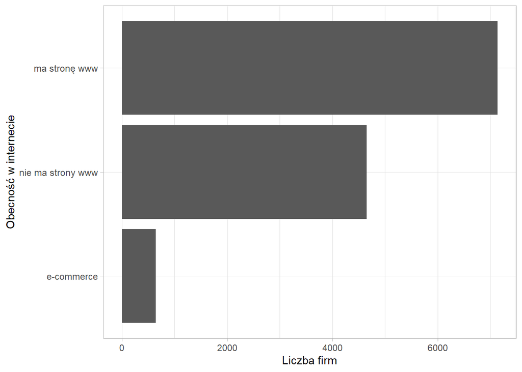

```r
make_barplot(zmienna = "obecnosc_w_internecie", xlab = "Obecność w internecie")
```

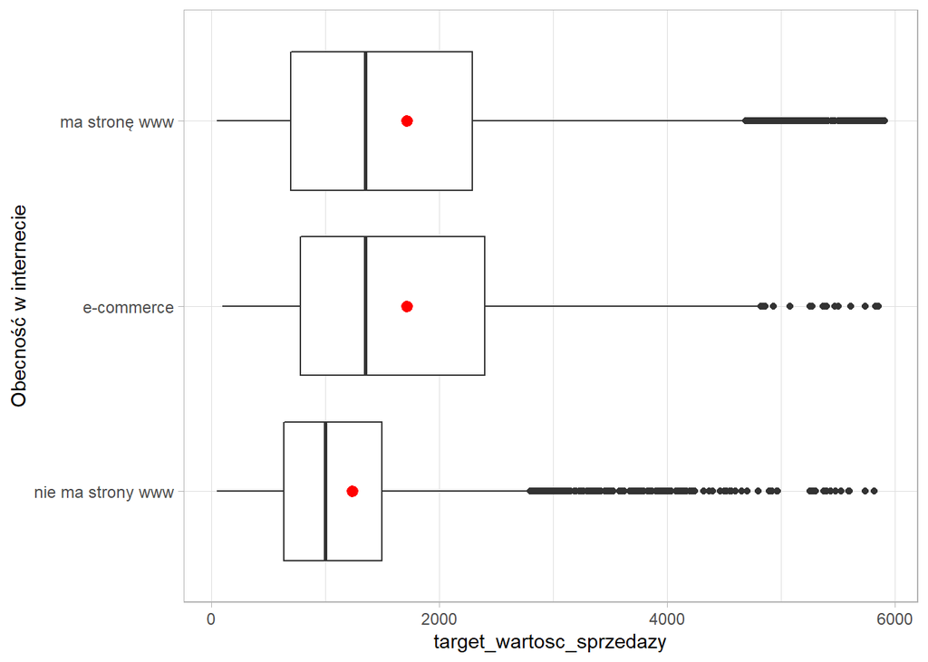

```r
make_boxplots(zmienna = "obecnosc_w_internecie", xlab = "Obecność w internecie")
```

```r
firmy <- firmy %>% mutate(obecnosc_w_internecie =
                            ifelse(obecnosc_w_internecie == "ma stronę www" |
                                     obecnosc_w_internecie == "e-commerce", "tak", "nie"))

firmy_duza_sprzedaz <- firmy_duza_sprzedaz %>% mutate(obecnosc_w_internecie =
                            ifelse(obecnosc_w_internecie == "ma stronę www" |
                                     obecnosc_w_internecie == "e-commerce", "tak", "nie"))
```

#### Po połączeniu poziomów dysproporcja nie jest znacząca, więc zmienna ta powinna dobrze różnicować firmy ze względu na wartość sprzedaży.

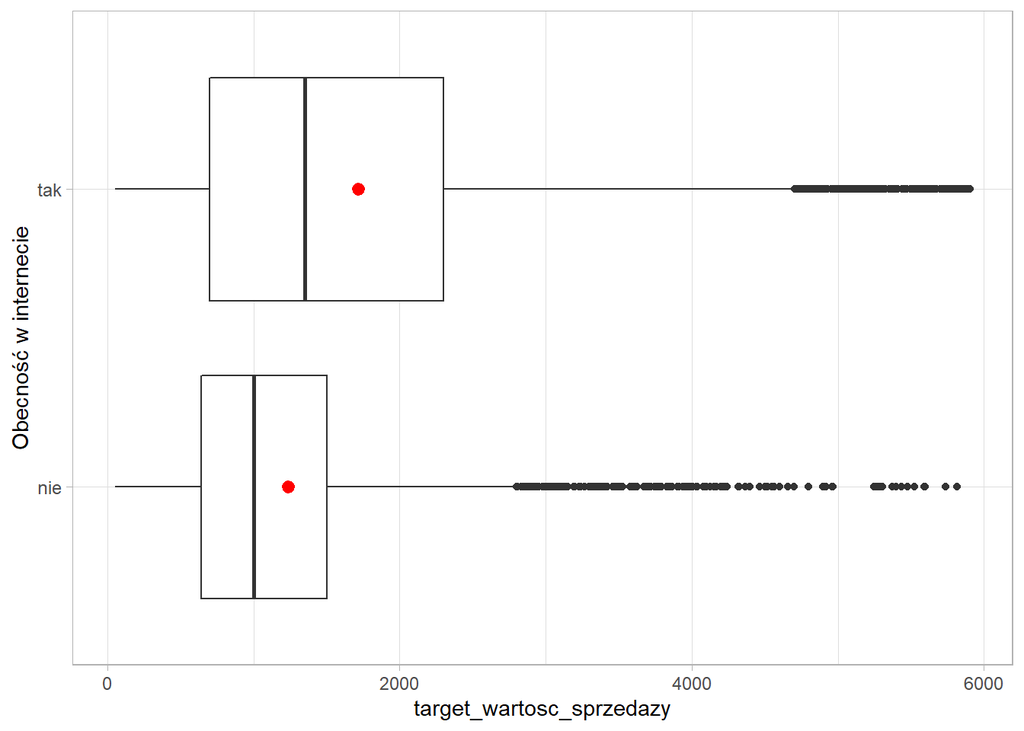

```r
make_boxplots(zmienna = "obecnosc_w_internecie", xlab = "Obecność w internecie")
```

# Analiza zależności

## Do zbadania zależności pomiędzy zmienną objaśnianą a zmiennymi objaśniającymi posłużę się współczynnikiem korelacji wielorakiej szacowanym przy pomocy modelu regresji.

#### Jak można zauważyć w poniższej tabeli, żadna zmienna nie ma silnego wpływu na zmienną wartość sprzedaży. Wpływ zmiennej obecnosc_w_internecie, rok_ostatniego_zamowienia, rok_rejestracji oraz kod_branzy (jak można było przypuszczać analizując wykresy) jest statystycznie istotny. Najsilniejszy wpływ na zmienną objaśnianą ma zmienna obecnosc_w_internecie oraz rok_ostatniego_zamowienia.

```r
zmienne_objasniajace = firmy %>% select(-target_wartosc_sprzedazy) %>% colnames(.)

R <- vector(length = length(zmienne_objasniajace))
R_kwadrat <- vector(length = length(zmienne_objasniajace))

for (i in 1:length(zmienne_objasniajace)){
  reg <- lm(firmy$target_wartosc_sprzedazy ~ factor(firmy[,zmienne_objasniajace[i]]))
  smr <- summary(reg)
  R[i] <- sqrt(smr$adj.r.squared)
  R_kwadrat[i] <- smr$adj.r.squared
}


tibble(zmienne_objasniajace, R, R_kwadrat) %>% arrange(desc(R))
```

```
## # A tibble: 8 x 3
##   zmienne_objasniajace           R R_kwadrat
##   <chr>                      <dbl>     <dbl>
## 1 obecnosc_w_internecie     0.202    0.0408
## 2 rok_ostatniego_zamowienia 0.190    0.0360
## 3 rok_rejestracji           0.161    0.0258
## 4 kod_branzy                0.135    0.0182
## 5 zrodlo_rejestr            0.0700   0.00491
## 6 liczba_pracownikow        0.0685   0.00469
## 7 kod_rynku                 0.0502   0.00252
## 8 nazwa_wojewodztwa         0.0384   0.00148
```

#### Do oceny siły wpływu zmiennych objaśniających na zmienną objaśnianą zostaną włączone tylko te zmienne, których wpływ jest istotny statystycznie (jak wspomniano wcześniej, zostanie dodana zmienna zrodlo_rejestr).

```r
summary(lm(data = firmy, target_wartosc_sprzedazy ~ obecnosc_w_internecie + rok_ostatniego_zamowienia + rok_rejestracji + kod_branzy + zrodlo_rejestr))
```

```
##
## Call:
## lm(formula = target_wartosc_sprzedazy ~ obecnosc_w_internecie +
##     rok_ostatniego_zamowienia + rok_rejestracji + kod_branzy +
##     zrodlo_rejestr, data = firmy)
##
## Residuals:
##     Min      1Q  Median      3Q     Max
## -2125.4  -734.8  -280.9   398.4  4564.7
##
## Coefficients:
##                             Estimate Std. Error t value Pr(>|t|)
## (Intercept)               -4.781e+05  2.461e+04 -19.429  < 2e-16 ***
## obecnosc_w_internecietak   4.559e+02  2.114e+01  21.563  < 2e-16 ***
## rok_ostatniego_zamowienia  2.196e+02  1.200e+01  18.299  < 2e-16 ***
## rok_rejestracji            1.793e+01  1.266e+00  14.162  < 2e-16 ***
## kod_branzy1171            -2.198e+02  6.262e+01  -3.509 0.000451 ***
## kod_branzy1386             6.638e+01  6.210e+01   1.069 0.285137
## kod_branzy1387             2.560e+02  6.599e+01   3.880 0.000105 ***
## kod_branzy1402            -1.264e+02  6.667e+01  -1.896 0.057965 .
## kod_branzy1433            -7.727e+01  7.011e+01  -1.102 0.270391
## kod_branzy1574            -1.148e+02  5.715e+01  -2.009 0.044515 *
## kod_branzy411             -1.440e+02  5.856e+01  -2.459 0.013959 *
## kod_branzy437             -6.256e+01  5.868e+01  -1.066 0.286336
## kod_branzy5               -1.859e+02  5.803e+01  -3.203 0.001365 **
## kod_branzy522             -6.326e+01  6.032e+01  -1.049 0.294298
## kod_branzy526              1.051e+01  5.872e+01   0.179 0.858023
## kod_branzy652              1.777e+02  6.554e+01   2.712 0.006700 **
## kod_branzy755             -2.048e+02  6.105e+01  -3.354 0.000798 ***
## kod_branzy848             -1.469e+01  6.154e+01  -0.239 0.811289
## kod_branzy907             -1.249e+02  6.888e+01  -1.813 0.069801 .
## kod_branzy968             -2.298e+00  6.495e+01  -0.035 0.971777
## kod_branzy98              -2.472e+02  5.859e+01  -4.219 2.47e-05 ***
## zrodlo_rejestrKRS          2.690e+02  4.529e+01   5.939 2.95e-09 ***
## ---
## Signif. codes:  0 '***' 0.001 '**' 0.01 '*' 0.05 '.' 0.1 ' ' 1
##
## Residual standard error: 1085 on 12409 degrees of freedom
## Multiple R-squared:  0.09545,    Adjusted R-squared:  0.09392
## F-statistic: 62.35 on 21 and 12409 DF,  p-value: < 2.2e-16
```

#### Poniżej przedstawiono jedynie istotne statystycznie parametry zmiennych mających istotny wpływ na zmienną objaśnianą. Dla zmiennych nienumerycznych informują one o ile przeciętnie zmieni się wartość zmiennej docelowej gdy wystąpi określony poziom danej zmiennej. Dla zmiennych numerycznych (które w analizowanym zbiorze przedstawiają lata) informują o ile przeciętnie zmieni się (wzrośnie gdy parametr jest dodatni lub zmaleje gdy jest ujemny) wartość sprzedaży gdy wartość zmiennej wzrośnie o rok.

```r
summary(lm(data = firmy, target_wartosc_sprzedazy ~ obecnosc_w_internecie + rok_ostatniego_zamowienia + rok_rejestracji + kod_branzy + zrodlo_rejestr)) %>% tidy() %>%
  filter(p.value <= 0.05) %>%
  select(term, estimate) %>% filter(term != "(Intercept)") %>%
  arrange(desc(estimate))
```

```
## # A tibble: 12 x 2
##    term                      estimate
##    <chr>                        <dbl>
##  1 obecnosc_w_internecietak     456.
##  2 zrodlo_rejestrKRS            269.
##  3 kod_branzy1387               256.
##  4 rok_ostatniego_zamowienia    220.
##  5 kod_branzy652                178.
##  6 rok_rejestracji               17.9
##  7 kod_branzy1574              -115.
##  8 kod_branzy411               -144.
##  9 kod_branzy5                 -186.
## 10 kod_branzy755               -205.
## 11 kod_branzy1171              -220.
## 12 kod_branzy98                -247.
```

## Na sam koniec zobaczymy czym charakteryzują się firmy które przyniosły firmie doradczej bardzo duże zyski. Może uda się zaobserwować coś ciekawego.

```r
firmy_comp <- firmy %>% mutate(typ = "pozostałe") %>%
  bind_rows(firmy_duza_sprzedaz %>% mutate(typ = "bardzo zyskowne"))
```

#### Do porównań firm które są zyskowne oraz bardzo zyskowne zostanie wykorzystany estymator frakcji poszczególnych poziomów cech. Przez odsetek/frakcję możemy rozumieć prawdopodobieństwo wystąpienia firmy o danej cesze która należy do danej grupy zyskowności. Jak widać poniżej, kategorie cechują się dużą liczebnością więc wnioskowanie powinno się charakteryzować dużą „mocą”.

```r
lista <- list("pozostałe" = firmy, "bardzo zyskowne" = firmy_duza_sprzedaz)

for (i in 1:2){
  print(paste0("Liczba firm z kategorii ", names(lista)[i], ": ", nrow(lista[[i]])))
}
```

```
## [1] "Liczba firm z kategorii pozostałe: 12431"
## [1] "Liczba firm z kategorii bardzo zyskowne: 1797"
```

#### W tym przypadku również stworzymy funkcje wyświetlające wykresy.

```r
make_barplots <- function(data = firmy_comp, zmienna = "kod_rynku", xlab = "Kod rynku",
                         ylab1 = "Liczba bardzo zyskownych firm", ylab2 = "Liczba pozostałych firm",
                         lab_size = 9){

  df1 <- data %>% filter(typ == "bardzo zyskowne")
  df2 <- data %>% filter(typ == "pozostałe")

  plt1 <- df1 %>%
  count(df1[[zmienna]]) %>%
  rename(zmienna = 1) %>%
  ggplot(aes(x = fct_reorder(zmienna, n, sum), y = n))+
  geom_col()+
  coord_flip()+
  xlab(xlab)+
  ylab(ylab1)+
  theme(axis.text = element_text(size = lab_size))

  plt2 <- df2 %>%
  count(df2[[zmienna]]) %>%
  rename(zmienna = 1) %>%
  ggplot(aes(x = fct_reorder(zmienna, n, sum), y = n))+
  geom_col()+
  coord_flip()+
  xlab("")+
  ylab(ylab2)+
  theme(axis.text = element_text(size = lab_size))

  plot_grid(plt1, plt2)
}


make_perc_barplots <- function(data = firmy_comp, zmienna = "kod_rynku", xlab = "Kod rynku",
                         ylab = "Procent firm", lab_size = 9){

  data %>%
  count(data[,c("typ", zmienna)]) %>%
  rename(typ = 1, zmienna = 2) %>%
  group_by(typ) %>%
  mutate(perc = n / sum(n)) %>%
  ggplot(aes(fct_reorder(zmienna, perc), perc))+
  geom_col(aes(fill = typ), position = "dodge")+
  coord_flip()+
  scale_y_continuous(labels = scales::percent_format())+
  xlab(xlab)+
  ylab(ylab)+
  theme(axis.text = element_text(size = lab_size))

}
```

#### Wśród bardzo zyskownych firm największym odsetkiem charakteryzują się firmy z województwa śląskiego. Może być to spowodowane tym, że na śląsku jest zlokalizowanych najwięcej firm z sektora przemysłowego, który cechuje się w porównaniu do innych sektorów największymi dochodami. Na poniższym wykresie widać, że dla województwa śląskiego odsetek bardzo zyskownych firm jest dużo większy od pozostałych. Dla innych województw różnice nie są aż tak widoczne. Można również zauważyć że w województwach najsłabiej rozwiniętych odsetek bardzo zyskownych firm jest niższy od pozostałych.

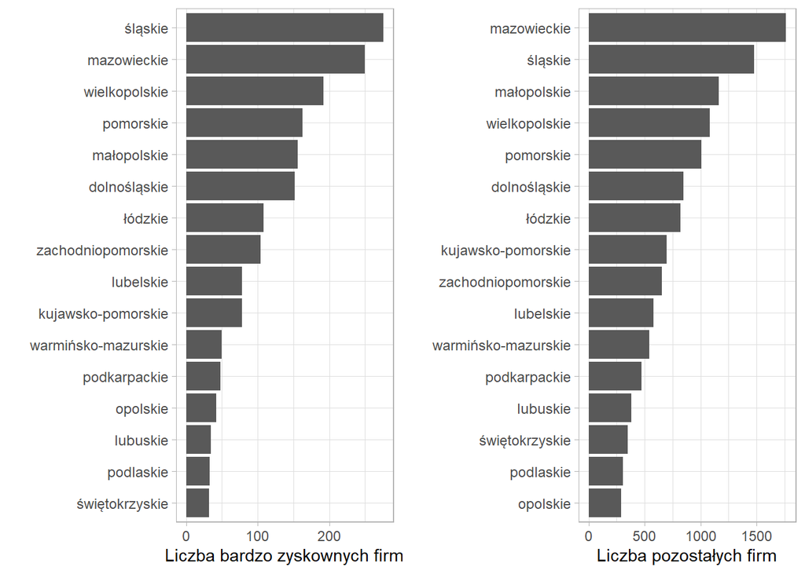

```r
make_barplots(zmienna = "nazwa_wojewodztwa", xlab = "")
```

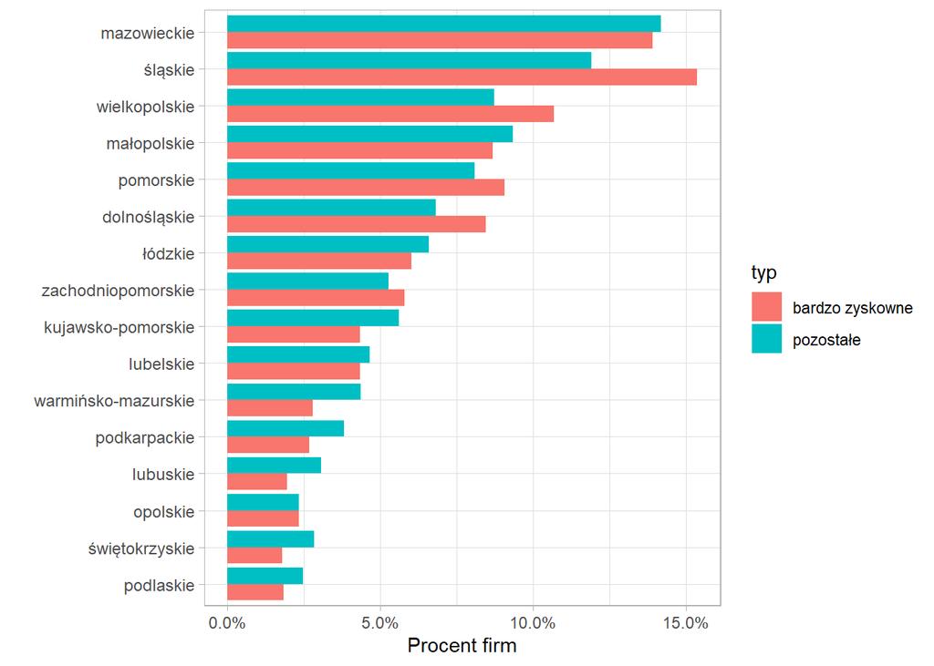

```r
make_perc_barplots(zmienna = "nazwa_wojewodztwa", xlab = "")
```

#### W przypadku kodu rynku widać znaczny wzrost odsetka bardzo zyskownych firm w porównaniu do odsetka wśród pozostałych na rynkach o kodach GDW, WAW, POW, WRW, KTW, KRW, SZW, GLW, GDW, TYW. Widać również rynki w których odsetek bardzo zyskownych firm jest dużo mniejszy od odsetka wśród pozostałych.

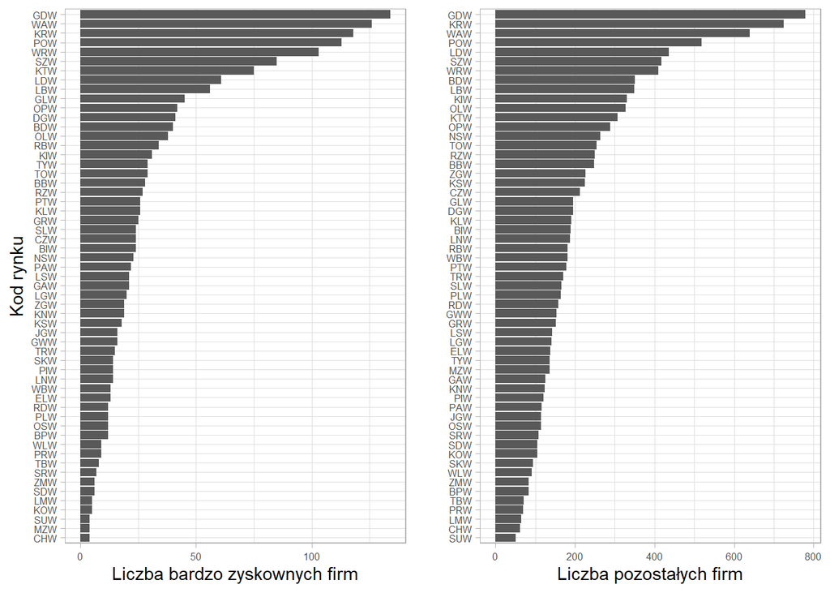

```r
make_barplots(zmienna = "kod_rynku", xlab = "Kod rynku", lab_size = 6)
```

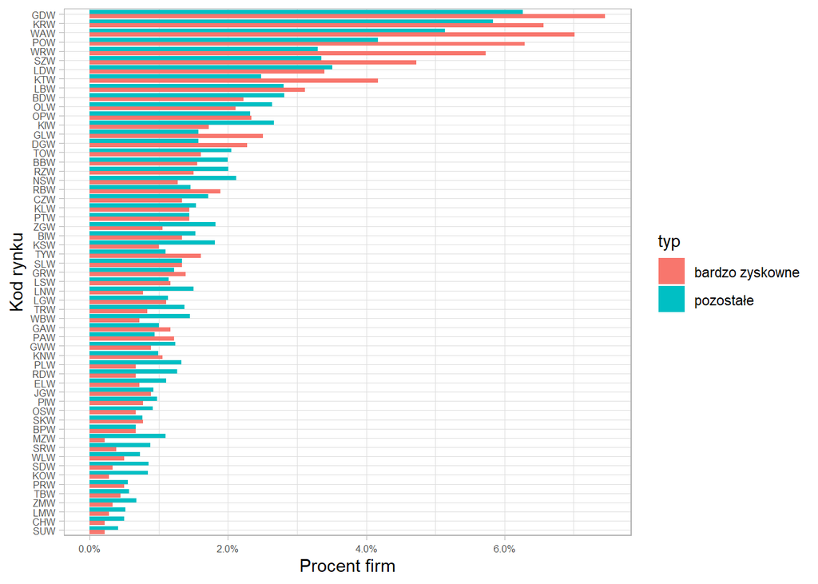

```r
make_perc_barplots(zmienna = "kod_rynku", xlab = "Kod rynku", lab_size = 6)
```

#### Odsetek firm ze względu na kod branży wśród bardzo zyskownych i pozostałych firm jest zróżnicowany. Pokrywa się to z wcześniejsza analizą. Widać, że dla branży 1574, 411, 1171 czy 98 odsetek firm bardzo zyskownych jest mniejszy od odsetka tych branż w grupie mniej zyskownych firm.

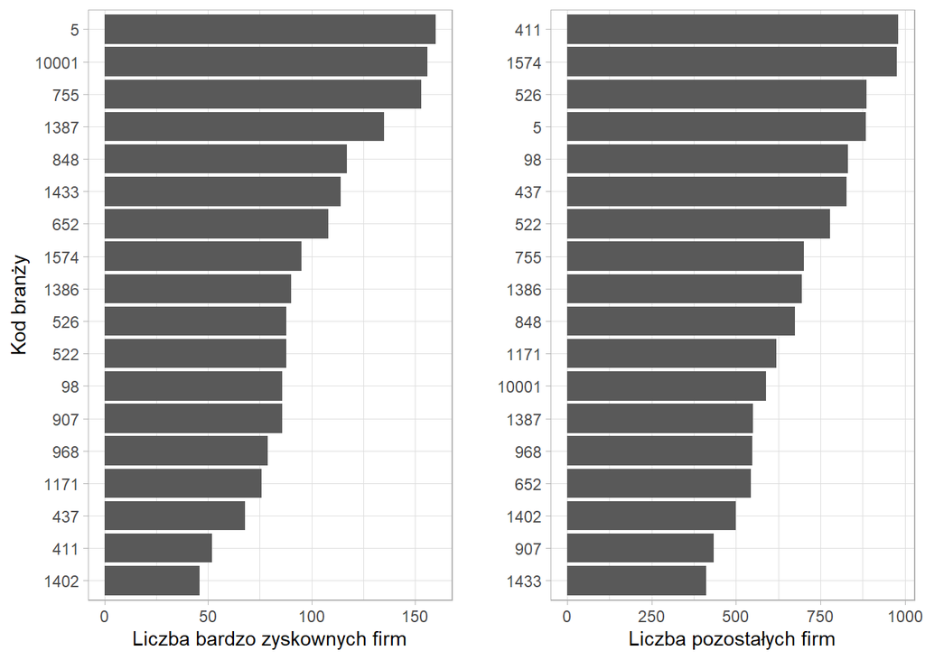

```r
make_barplots(zmienna = "kod_branzy", xlab = "Kod branży")
```

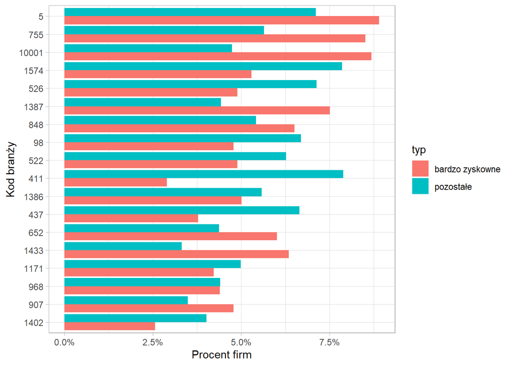

```r
make_perc_barplots(zmienna = "kod_branzy", xlab = "Kod branży")
```

#### Poniższy wykres bardzo dobrze oddaje rzeczywistą sytuację. Doskonale widać, że odsetek firm zatrudniających powyżej 10 osób wśród bardzo zyskownych firm jest większy od odsetka tego rodzaju firm dla pozostałych. Dla firm zatrudniających mniej jak 10 osób sytuacja ta jest odmienna. Należy jednak zaznaczyć, że odsetek mniejszych firm w grupie bardzo zyskownych i pozostałych firm jest bardzo duży, znacznie większy od firm zatrudniających powyżej 10 osób.

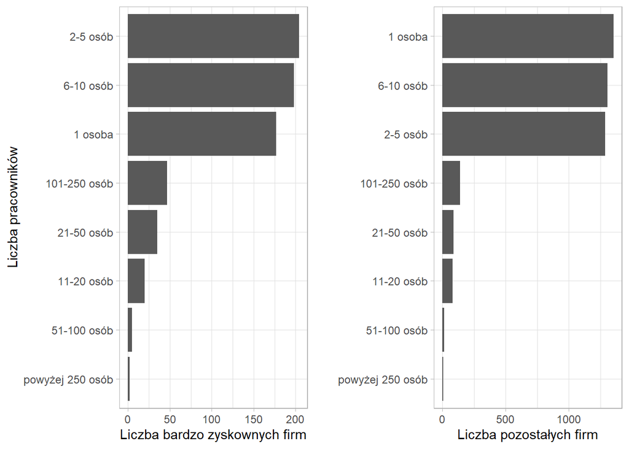

```r
make_barplots(data = firmy_comp %>% na.omit(), zmienna = "liczba_pracownikow", xlab = "Liczba pracowników")
```

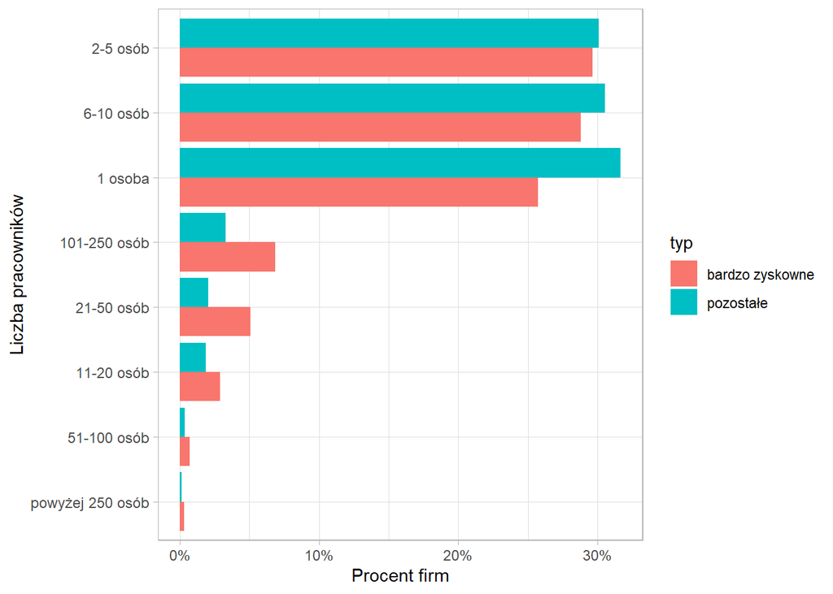

```r
make_perc_barplots(data = firmy_comp %>% na.omit(), zmienna = "liczba_pracownikow", xlab = "Liczba pracowników")
```

#### Większy jest odsetek bardzo zyskownych firm zarejestrowanych w KRS aniżeli tych które generują mniejsze zyski. Pomino tego liczba firm zarejestrowanych w CEIDG jest znacznie większa od tych które są zarejestrowane w KRS. Poniższy wykres jest dodatkowym potwierdzeniem poprzedniego wniosku.

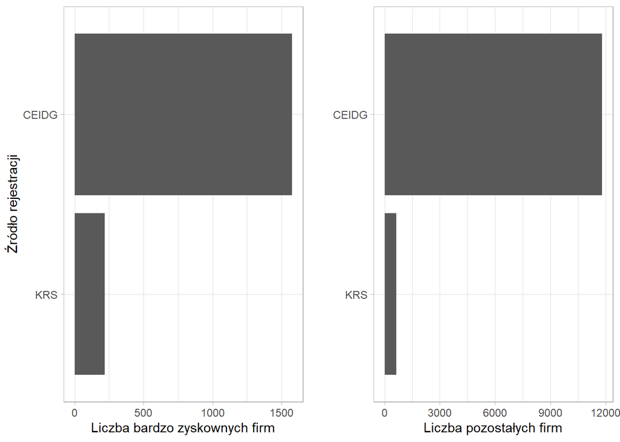

```r
make_barplots(zmienna = "zrodlo_rejestr", xlab = "Źródło rejestracji")
```

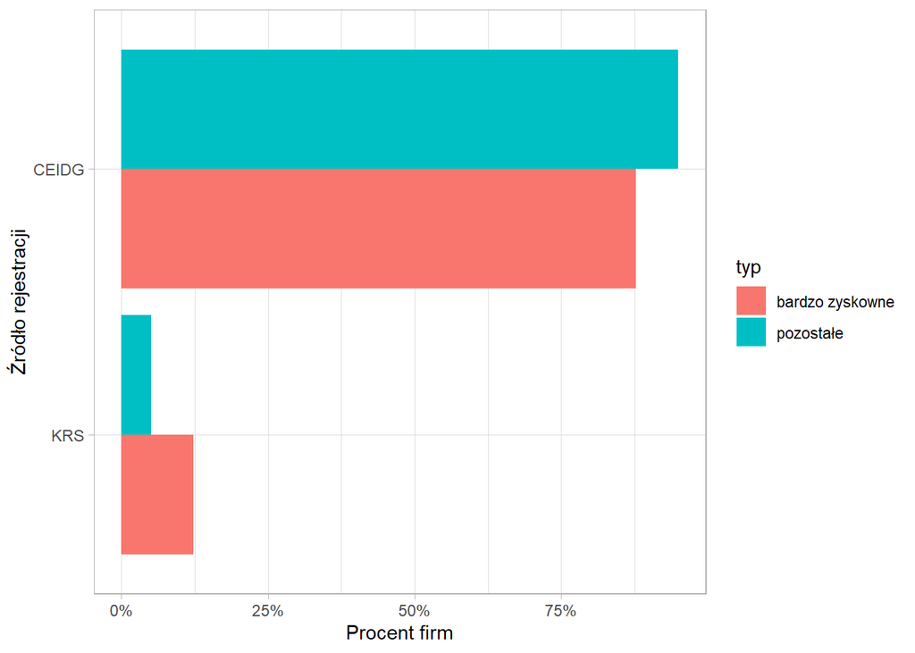

```r
make_perc_barplots(zmienna = "zrodlo_rejestr", xlab = "Źródło rejestracji")
```